# Import Libraries

```python
# Uncomment and install packages if necessary
#!pip install xgboost

# install specific version for compatibility
#!pip install scikit-learn==1.2.2
#!pip install imbalanced-learn
```

```python
import sys
import os

# Add the project directory to Python's path
project_path = os.path.abspath(os.path.join(os.getcwd(), ".."))
if project_path not in sys.path:
    sys.path.append(project_path)

# Verify the path addition (optional)
print("Project path added to sys.path:", project_path)
```

```
Project path added to sys.path: C:\Users\yafa917\OneDrive - HP Inc\Documents\GitHub\Classification\classification_loan_acceptance
```

```python
# Import required libraries
import pandas as pd
import numpy as np
import matplotlib.pyplot as plt
import seaborn as sns
import xgboost as xgb

# Machine learning tools
from sklearn.model_selection import train_test_split
from sklearn.impute import SimpleImputer
from sklearn.preprocessing import StandardScaler, OneHotEncoder
from sklearn.compose import ColumnTransformer
from sklearn.pipeline import Pipeline
from sklearn.ensemble import RandomForestClassifier, GradientBoostingClassifier
from sklearn.linear_model import LogisticRegression
from xgboost import XGBClassifier

# utilized functions
from src.utils import load_excel, train_model, tune_hyperparameters, evaluate_model, plot_confusion_matrix
from src.config import RANDOM_STATE

# Metrics for evaluation
from sklearn.metrics import classification_report, confusion_matrix, roc_auc_score, f1_score, accuracy_score, precision_score, recall_score, roc_curve

# Data balancing
from imblearn.over_sampling import SMOTE

# Suppress warnings
import warnings
warnings.filterwarnings("ignore")

print("All libraries imported successfully!")
```

```
All libraries imported successfully!
```

# Load Dataset

```python
from src.utils import load_excel

raw_data_path = os.path.join(project_path, "data", "raw")
data = load_excel(raw_data_path, "Bank_Personal_Loan_Modelling.xlsx", "Data")
data.head()
```

```
File 'Bank_Personal_Loan_Modelling.xlsx' loaded successfully!
```

|  | ID | Age | Experience | Income | ZIP Code | Family | CCAvg | Education | Mortgage | Personal Loan | Securities Account | CD Account | Online | CreditCard |
| --- | --- | --- | --- | --- | --- | --- | --- | --- | --- | --- | --- | --- | --- | --- |
| 0 | 1 | 25 | 1 | 49 | 91107 | 4 | 1.6 | 1 | 0 | 0 | 1 | 0 | 0 | 0 |
| 1 | 2 | 45 | 19 | 34 | 90089 | 3 | 1.5 | 1 | 0 | 0 | 1 | 0 | 0 | 0 |
| 2 | 3 | 39 | 15 | 11 | 94720 | 1 | 1.0 | 1 | 0 | 0 | 0 | 0 | 0 | 0 |
| 3 | 4 | 35 | 9 | 100 | 94112 | 1 | 2.7 | 2 | 0 | 0 | 0 | 0 | 0 | 0 |
| 4 | 5 | 35 | 8 | 45 | 91330 | 4 | 1.0 | 2 | 0 | 0 | 0 | 0 | 0 | 1 |

## Inspect Dataset

```python
print("Dataset shape:", data.shape)
print("\nDataset info:")
print(data.info())
```

```
Dataset shape: (5000, 14)

Dataset info:
<class 'pandas.core.frame.DataFrame'>
RangeIndex: 5000 entries, 0 to 4999
Data columns (total 14 columns):
 #   Column              Non-Null Count  Dtype
---  ------              --------------  -----
 0   ID                  5000 non-null   int64
 1   Age                 5000 non-null   int64
 2   Experience          5000 non-null   int64
 3   Income              5000 non-null   int64
 4   ZIP Code            5000 non-null   int64
 5   Family              5000 non-null   int64
 6   CCAvg               5000 non-null   float64
 7   Education           5000 non-null   int64
 8   Mortgage            5000 non-null   int64
 9   Personal Loan       5000 non-null   int64
 10  Securities Account  5000 non-null   int64
 11  CD Account          5000 non-null   int64
 12  Online              5000 non-null   int64
 13  CreditCard          5000 non-null   int64
dtypes: float64(1), int64(13)
memory usage: 547.0 KB
None
```

All variables in our dataset is numerical and there is no missing data. Good news!

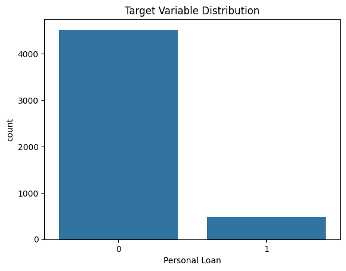

```python
# Target variable is 'Personal Loan' (1 = accepted, 0 = not accepted)
target = "Personal Loan"

# Target distribution
sns.countplot(x=target, data=data)
plt.title("Target Variable Distribution")
plt.show()
```

The target variable is highly imbalanced, only around 10% of the customers have converted (target variable). I will apply balancing for the data.

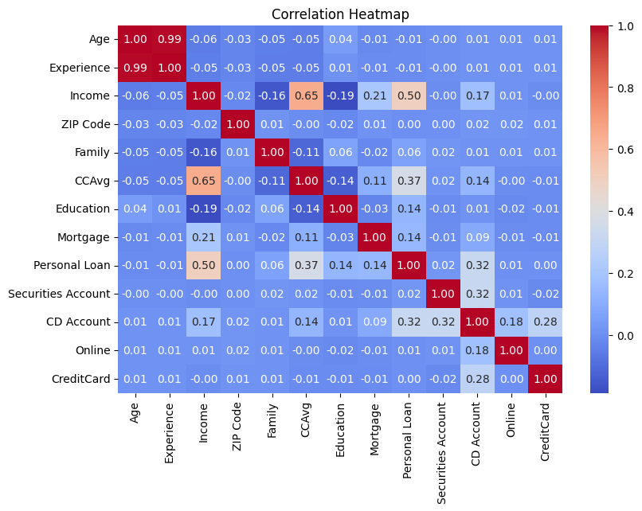

```python
# Correlation heatmap for numerical features
numerical_cols = data.select_dtypes(include=["float64", "int64"]).columns.drop("ID")
plt.figure(figsize=(9, 6))
sns.heatmap(data[numerical_cols].corr(), annot=True, fmt=".2f", cmap="coolwarm")
plt.title("Correlation Heatmap")
plt.show()
```

'Age' and 'Experience' variables have almost perfect correlation, naturally. Since both have the same correlation with the target variable, we can remove either. Another pair of variables with high correlation are 'CCAvg' (Credit Card Avg Payment) and 'Income'. However, this pair of variables can provide significant information for the target variable, therefore, I will keep both.

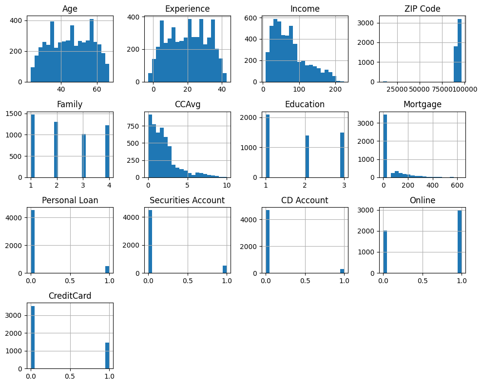

```python
# Plot distributions for numeric columns
numeric_columns = data.select_dtypes(include="number").columns.drop("ID")
data[numeric_columns].hist(figsize=(10, 8), bins=20)
plt.tight_layout()
plt.show()
```

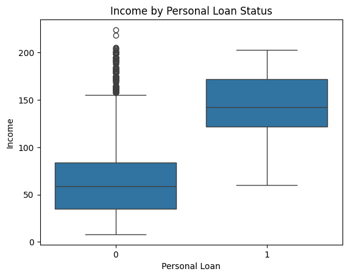

```python
# Boxplot for Income by Personal Loan status
sns.boxplot(x=target, y="Income", data=data)
plt.title("Income by Personal Loan Status")
plt.show()
```

Individuals who get personal loans have a higher income in average and a higher distribtuion of income.

## Preprocessing

```python
# Define features and target
features = data.drop(columns=['ID', 'Experience', target])
labels = data[target]
```

```python
# Uncomment to handle missing data and impute with median values. Current data has no missing values.
# features = features.fillna(features.median())
```

### Split Data

```python
# Split data into train and test sets
X_train, X_test, y_train, y_test = train_test_split(features, labels, test_size=0.2, random_state=35)
```

```python
# Numerical vars
numerical_cols = features.select_dtypes(include=["float64", "int64"]).columns
print("Numerical Columns:", numerical_cols)

# Uncomment if there are categorical vars
#categorical_cols = features.select_dtypes(include=["object"]).columns
#print("Categorical Columns:", categorical_cols)
```

```
Numerical Columns: Index(['Age', 'Income', 'ZIP Code', 'Family', 'CCAvg', 'Education', 'Mortgage',
       'Securities Account', 'CD Account', 'Online', 'CreditCard'],
      dtype='object')
```

```python
# Preprocessing pipeline - handles numerical columns as is. Uncomment below if there are categorical vars.
preprocessor = ColumnTransformer(
    transformers=[
        ("num", Pipeline(steps=[("imputer", SimpleImputer(strategy="median")),
                                ("scaler", StandardScaler())]), numerical_cols)
#        ,("cat", OneHotEncoder(handle_unknown="ignore"), categorical_cols)
    ]
)

# Fit and transform the training data
X_train_transformed = preprocessor.fit_transform(X_train)

# Transform the testing data
X_test_transformed = preprocessor.transform(X_test)

# Display the transformed data shapes
print("Transformed X_train shape:", X_train_transformed.shape)
print("Transformed X_test shape:", X_test_transformed.shape)
```

```
Transformed X_train shape: (4000, 11)
Transformed X_test shape: (1000, 11)
```

### Balance Data

I use SMOTE to create synthetic samples for the minority class (in our case, loan acceptance) to address the class imbalance.

```python
# Balance the training set using SMOTE
smote = SMOTE(random_state=35)
X_train_balanced, y_train_balanced = smote.fit_resample(X_train_transformed, y_train)

# Check the class distribution after balancing
print("\nOriginal target distribution:")
print(y_train.value_counts())
print("\nBalanced target distribution:")
print(pd.Series(y_train_balanced).value_counts())
```

```
Original target distribution:
0    3608
1     392
Name: Personal Loan, dtype: int64

Balanced target distribution:
0    3608
1    3608
Name: Personal Loan, dtype: int64
```

### Save Processed Data

```python
# Define the target folder
processed_data_dir = os.path.abspath("../data/processed")
os.makedirs(processed_data_dir, exist_ok=True)

# Define file paths
X_train_path = os.path.join(processed_data_dir, "X_train.csv")
X_test_path = os.path.join(processed_data_dir, "X_test.csv")
y_train_path = os.path.join(processed_data_dir, "y_train.csv")
y_test_path = os.path.join(processed_data_dir, "y_test.csv")

# Convert to DataFrames
X_train_balanced_df = pd.DataFrame(X_train_balanced)
X_test_transformed_df = pd.DataFrame(X_test_transformed)

# Save the processed datasets
X_train_balanced_df.to_csv(X_train_path, index=False)
X_test_transformed_df.to_csv(X_test_path, index=False)
pd.DataFrame(y_train_balanced).to_csv(y_train_path, index=False)
pd.DataFrame(y_test).to_csv(y_test_path, index=False)

print(f"Processed data saved successfully in: {processed_data_dir}")
```

```
Processed data saved successfully in: C:\Users\yafa917\OneDrive - HP Inc\Documents\GitHub\Classification\classification_loan_acceptance\data\processed
```

## Define and Train Models

```python
# Define the models to compare and set the random state
models = {
    "Logistic Regression": LogisticRegression(max_iter = 1000, random_state=RANDOM_STATE),
    "Random Forest": RandomForestClassifier(n_estimators=100, random_state=RANDOM_STATE),
    "Gradient Boosting": GradientBoostingClassifier(random_state=RANDOM_STATE),
    "XGBoost": XGBClassifier( eval_metric="logloss", random_state=RANDOM_STATE)
}
```

### Train Models

```python
# Train and evaluate each model
results = {}
trained_models = {}

for model_name, model in models.items():
    print(f"Training and evaluating {model_name}...")

    params = model.get_params()
    # Train the model
    trained_model = train_model(
        X_train=X_train_balanced,
        y_train=y_train_balanced,
        model_type=model_name.lower().replace(" ", "_"),
        **params
    )

    # Store the trained model
    trained_models[model_name] = trained_model

    # Evaluate the model
    metrics = evaluate_model(trained_model, X_test_transformed, y_test)
    results[model_name] = metrics

print("\nAll models completed!")
```

```
Training and evaluating Logistic Regression...
Training and evaluating Random Forest...
Training and evaluating Gradient Boosting...
Training and evaluating XGBoost...

All models completed!
```

### Compare Models

```python
# Convert DataFrame for comparison
results_df = pd.DataFrame(results).T
print("\nModel Comparison:")
print(results_df)
```

```
Model Comparison:
                     Accuracy    Recall  Precision  F1-Score
Logistic Regression     0.908  0.852273   0.487013  0.619835
Random Forest           0.988  0.909091   0.952381  0.930233
Gradient Boosting       0.985  0.920455   0.910112  0.915254
XGBoost                 0.984  0.920455   0.900000  0.910112
```

Our business goal is to predict the loan buyers and it would be costly to the company to miss classify those clients who are likely to buy a loan. For this purpose, it is crucial to minimize false negatives, which can be identified by maximizing Recall.

Gradient Boosting and XGBoost models are the models with the highest Recall and the primary candidates for best performing models. On top of that, Gradient Boosting has slightly better Accuracy, Precision and F1 Score than XGBoost.

Random Forest is also a strong candidate, since it has the highest F1 Score and Precision. In this business case, false positives are not a high risk. But if they were, then Random Forest would be a better option with overall best performance.

### Confusion Matrices

```
Confusion Matrix for Logistic Regression:
```

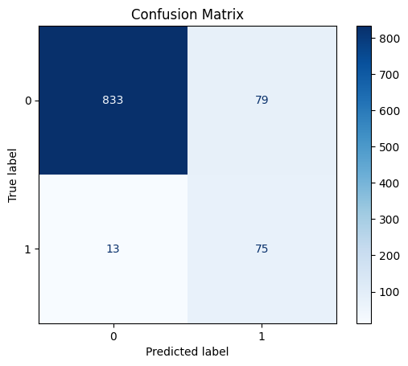

```
--------------------------------------------------
Confusion Matrix for Random Forest:
```

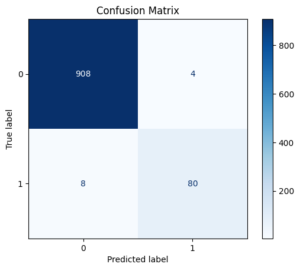

```
--------------------------------------------------
Confusion Matrix for Gradient Boosting:
```

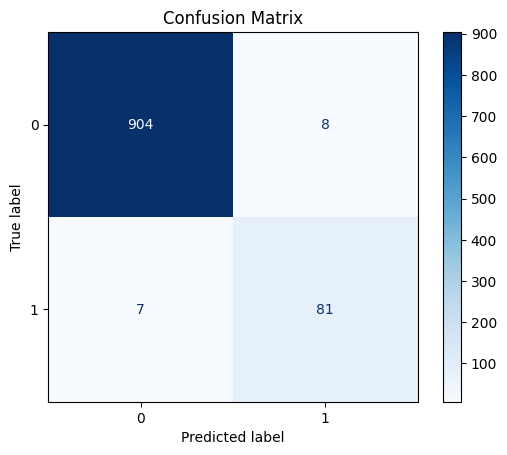

```
--------------------------------------------------
Confusion Matrix for XGBoost:
```

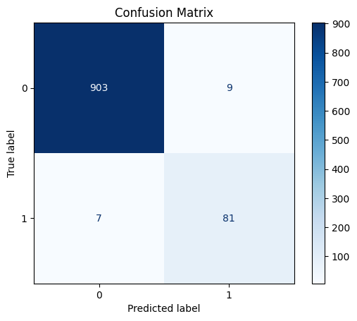

```python
for model_name, trained_model in trained_models.items():
    print(f"Confusion Matrix for {model_name}:")
    plot_confusion_matrix(trained_model, X_test_transformed, y_test)
    print("-" * 50)
```

### Feature Importance

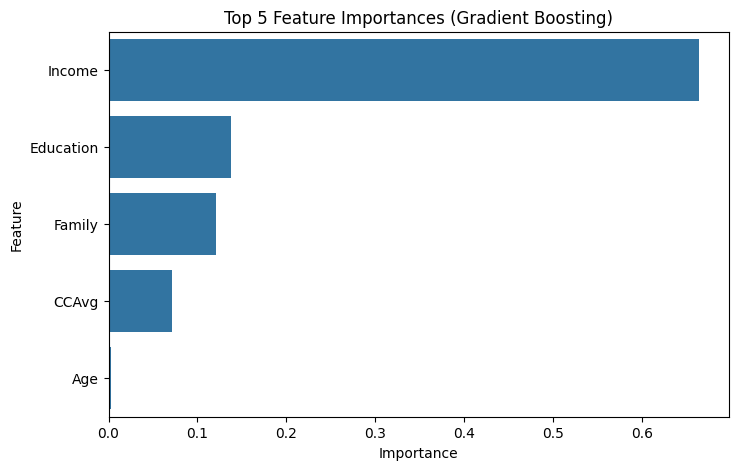

```
Top 5 Important Features (Gradient Boosting):
     Feature  Importance
1     Income    0.663701
5  Education    0.137459
3     Family    0.121305
4      CCAvg    0.071601
0        Age    0.002663
```

```python
# Feature importance for Gradient Boosting model
gb_importances = trained_models["Gradient Boosting"].feature_importances_

# DataFrame for feature importances
gb_importance_df = pd.DataFrame({
    "Feature": numerical_cols,
    "Importance": gb_importances
}).sort_values(by="Importance", ascending=False)

# Plot
plt.figure(figsize=(8, 5))
sns.barplot(x="Importance", y="Feature", data=gb_importance_df.head(5))
plt.title("Top 5 Feature Importances (Gradient Boosting)")
plt.xlabel("Importance")
plt.ylabel("Feature")
plt.show()

print("\nTop 5 Important Features (Gradient Boosting):")
print(gb_importance_df.head(5))
```

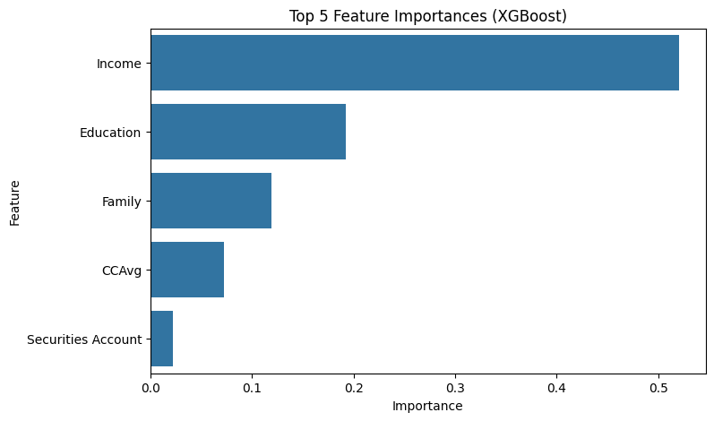

```
Top 5 Important Features (XGBoost):
              Feature  Importance
1              Income    0.520961
5           Education    0.192099
3              Family    0.118835
4               CCAvg    0.072824
7  Securities Account    0.022510
```

```python
# Feature importance for XGBoost model
xgb_importances = trained_models["XGBoost"].feature_importances_

# DataFrame for feature importances
xgb_importance_df = pd.DataFrame({
    "Feature": numerical_cols,
    "Importance": xgb_importances
}).sort_values(by="Importance", ascending=False)

# Plot
plt.figure(figsize=(8, 5))
sns.barplot(x="Importance", y="Feature", data=xgb_importance_df.head(5))
plt.title("Top 5 Feature Importances (XGBoost)")
plt.xlabel("Importance")
plt.ylabel("Feature")
plt.show()

print("\nTop 5 Important Features (XGBoost):")
print(xgb_importance_df.head(5))
```

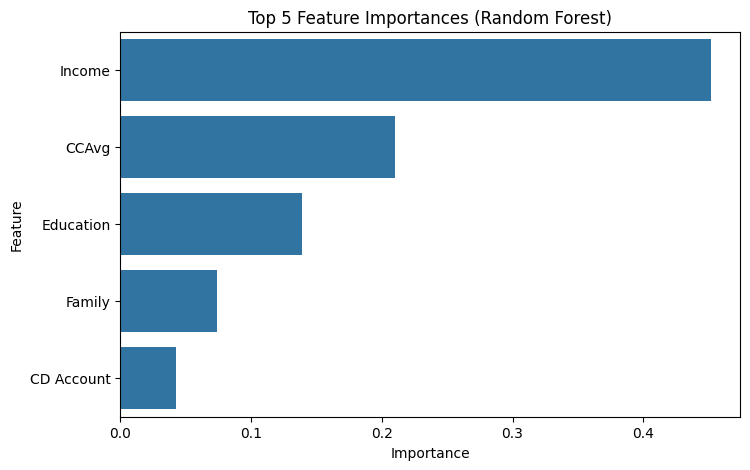

```
Top 5 Important Features (Random Forest):
      Feature  Importance
1      Income    0.451445
4       CCAvg    0.209765
5   Education    0.139287
3      Family    0.073704
8  CD Account    0.042320
```

```python
# Feature importance for Random Forest
rf_importances = trained_models["Random Forest"].feature_importances_

# DataFrame for feature importances
rf_importance_df = pd.DataFrame({
    "Feature": numerical_cols,
    "Importance": rf_importances
}).sort_values(by="Importance", ascending=False)

# Plot
plt.figure(figsize=(8, 5))
sns.barplot(x="Importance", y="Feature", data=rf_importance_df.head(5))
plt.title("Top 5 Feature Importances (Random Forest)")
plt.xlabel("Importance")
plt.ylabel("Feature")
plt.show()

print("\nTop 5 Important Features (Random Forest):")
print(rf_importance_df.head(5))
```

From the top 5 features of the best performer models, we can see income, education, family and credit card spending are the most important features, consistently. The teams should focus on these features for their decisions.

### Model Refinement

#### Gradient Boosting

```python
from sklearn.metrics import make_scorer, recall_score
from sklearn.ensemble import GradientBoostingClassifier
from src.utils import tune_hyperparameters

param_grid = {
    "n_estimators": [100, 200, 300],
    "learning_rate": [0.01, 0.05, 0.1],
    "max_depth": [3, 5, 7]
}

# Perform Grid Search
best_params = tune_hyperparameters(
    model=trained_models["Gradient Boosting"],
    param_grid=param_grid,
    X_train=X_train_balanced,
    y_train=y_train_balanced,
    scoring="recall"
)

# Output the best parameters and score
print("Best Parameters (Recall):", best_params)
```

```
Best Parameters: {'learning_rate': 0.1, 'max_depth': 5, 'n_estimators': 300}
Best Parameters (Recall): GradientBoostingClassifier(max_depth=5, n_estimators=300, random_state=35)
```

Best hyperparameters for Gradient Boosting are:

```
- learning rate: 0.1
- max_depth: 5
- n_estimators: 300
```

#### Retrain Gradient Boosting

```
Training with best parameters...
Done!
Evaluating...
Done!

Final Model Metrics:
Accuracy: 0.9900
Recall: 0.9318
Precision: 0.9535
F1-Score: 0.9425
```

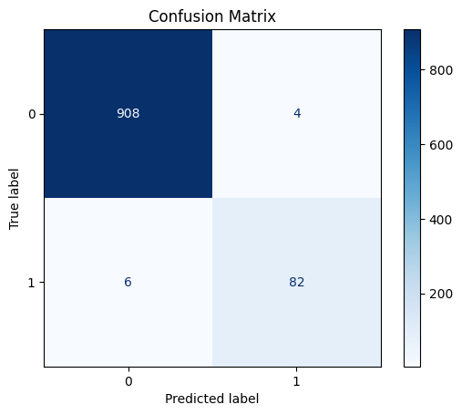

```python
from src.utils import train_model, evaluate_model, plot_confusion_matrix
from src.config import RANDOM_STATE

# Best parameters for Gradient Boosting
best_params = {
    "learning_rate": 0.1,
    "max_depth": 5,
    "n_estimators": 300
}

# Train the final Gradient Boosting model with the best parameters
print("Training with best parameters...")
final_gb_model = train_model(
    X_train=X_train_balanced,
    y_train=y_train_balanced,
    model_type="gradient_boosting",
    **best_params  # Pass the tuned parameters
)
print("Done!")

# Evaluate the final model
print("Evaluating...")
final_metrics = evaluate_model(final_gb_model, X_test_transformed, y_test)
print("Done!")

# Print evaluation metrics
print("\nFinal Model Metrics:")
for metric, value in final_metrics.items():
    if isinstance(value, float):  # Ensure proper formatting for numeric values
        print(f"{metric}: {value:.4f}")
    else:
        print(f"{metric}: {value}")

# Plot the confusion matrix
plot_confusion_matrix(final_gb_model, X_test_transformed, y_test)
```

#### Refine XGBoost

```
Best Parameters: {'colsample_bytree': 0.8, 'learning_rate': 0.05, 'max_depth': 5, 'n_estimators': 300, 'subsample': 1.0}
Tuning hyperparamters completed!

Best XGBoost Model Metrics:
Accuracy: 0.9840
Recall: 0.8864
Precision: 0.9286
F1-Score: 0.9070
```

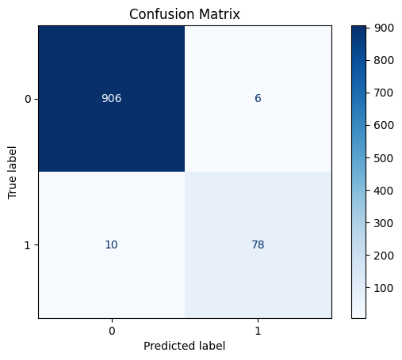

```python
from sklearn.model_selection import GridSearchCV
from xgboost import XGBClassifier
# Define the parameter grid
param_grid_xgb = {
    "n_estimators": [100, 200, 300],
    "learning_rate": [0.01, 0.05, 0.1],
    "max_depth": [3, 5, 7],
    "subsample": [0.8, 1.0],
    "colsample_bytree": [0.8, 1.0]
}

# Perform hyperparameter tuning for XGBoost
best_xgb_model = tune_hyperparameters(
    X_train=X_train_balanced,
    y_train=y_train_balanced,
    model=trained_models["XGBoost"],
    param_grid=param_grid_xgb,
    scoring="recall"
)
print("Tuning hyperparamters completed!")

# Evaluate the best XGBoost model
xgb_metrics = evaluate_model(best_xgb_model, X_test_transformed, y_test)

# Print evaluation metrics
print("\nBest XGBoost Model Metrics:")
for metric, value in xgb_metrics.items():
    if isinstance(value, float):
        print(f"{metric}: {value:.4f}")
    else:
        print(f"{metric}: {value}")

# Plot the confusion matrix
plot_confusion_matrix(best_xgb_model, X_test_transformed, y_test)
```

Best hyperparameters for XGBoost are:

```
- colsample_bytree: 0.8
- learning rate: 0.05
- max_depth: 5
- n_estimators: 300
- subsample: 1.0
```

The refined model has a lower recall score in the test data, indicating overfitting of the training data. Pretuned XGBoost model generalizes better.

### Cross Validation

```python
from sklearn.model_selection import cross_val_score
from sklearn.ensemble import GradientBoostingClassifier

# Initialize the model
final_gb_model = GradientBoostingClassifier(
    learning_rate=0.1,
    max_depth=5,
    n_estimators=300,
    random_state=35
)

# Perform cross-validation
gb_cv_scores = cross_val_score(
    estimator=final_gb_model,
    X=X_train_balanced,
    y=y_train_balanced,
    cv=5,
    scoring="recall"
)

# Output the results
print("Gradient Boosting Cross-Validation Scores (Recall):", gb_cv_scores)
print("Mean Cross-Validated Recall:", gb_cv_scores.mean())
```

```
Gradient Boosting Cross-Validation Scores (Recall): [0.95706371 0.99861304 0.99583911 0.99861496 0.99861496]
Mean Cross-Validated Recall: 0.989749155720164
```

The refined model has consistently high recall scores in the 5 folds of subsets with high mean and low std. This ensures the model performs with high efficiency and reliability.

Gradient Boosting (GB) after tuning for best paramters have these advantages over other models (initial and tuned XGBoost):

1. Achieves a higher recall score than initial model, demonstrating successful optimization for minimizing False Negatives.
2. Shows better alignment between training (cross-validation) and test performance. So it generalizes more effectively than XGBoost in this scenario.
3. Strikes a balance between fitting and predictive power, making it the more reliable model for production.

## Save Model

```python
import joblib

output_path = os.path.abspath("../models") # Go one level up from wd
os.makedirs(output_path, exist_ok=True)
file_path = os.path.join(output_path, f"gradient_boosting.joblib")

final_gb_model.fit(X_train_balanced, y_train_balanced)

# Save the model
joblib.dump(final_gb_model, file_path)
print(f"Model saved successfully at: {file_path}")
```

```
Model saved successfully at: C:\Users\yafa917\OneDrive - HP Inc\Documents\GitHub\Classification\classification_loan_acceptance\models\gradient_boosting.joblib
```